# lof

```python
import numpy as np
import pandas as pd
import matplotlib.pyplot as plt
import seaborn as sns
import plotly.express as px
import plotly.offline as pyo
import plotly.figure_factory as ff
import plotly.graph_objects as go

from sklearn.datasets import make_blobs
from sklearn.neighbors import LocalOutlierFactor
```

**A synthetic dataset of 300 samples is generated using make_blobs. The data is clustered and has a standard deviation of 2.**

```python
data = make_blobs(n_samples=300, cluster_std=2.0, random_state=10)[0]
data[:5]
```

```
array([[  4.64616033,   5.03253239],
       [  1.81963552,  -5.03357756],
       [  0.89059085,   3.41070216],
       [  0.61174827,   2.26068253],
       [  6.01229431, -10.52657552]])
```

**A scatter plot to visualize the data points.**

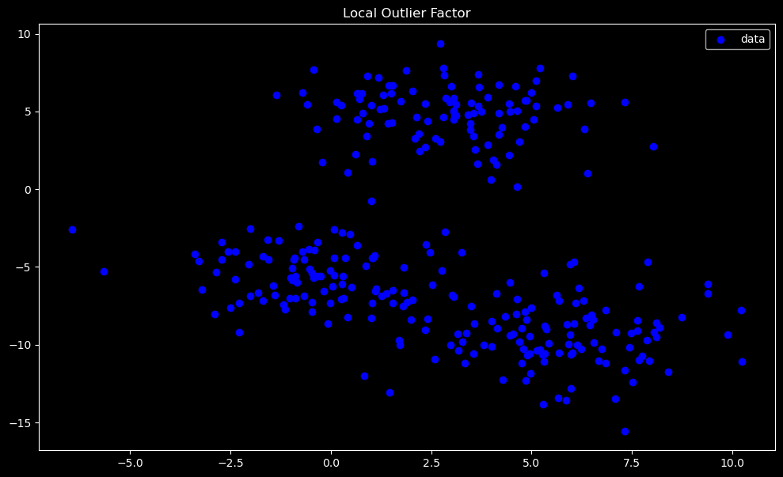

```python
plt.style.use('dark_background')
plt.figure(figsize=(12, 7))
plt.scatter(data[:, 0], data[:, 1], label='data', c='blue')
plt.title('Local Outlier Factor')
plt.legend()
```

**A density heatmap to highlight areas of dense data with a scatter plot overlaid on top of the heatmap representing data.**

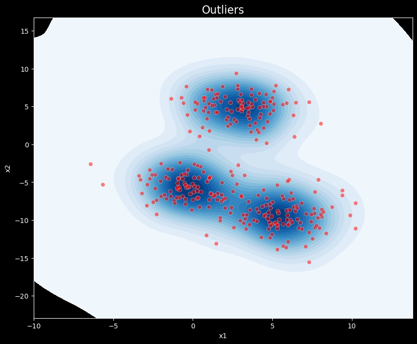

```python
plt.style.use('dark_background')

plt.figure(figsize=(10, 8))

sns.kdeplot(data=tmp, x='x1', y='x2', cmap='Blues', fill=True, thresh=0, levels=20)

sns.scatterplot(data=tmp, x='x1', y='x2', color='red', alpha=0.5, edgecolor='white', linewidth=0.5)

plt.title('Outliers', fontsize=16)
plt.xlabel('x1')
plt.ylabel('x2')

plt.show()
```

**The Local Outlier Factor algorithm with 20 neighbors. The fit_predict method is used to fit the model and predict the labels for each point. A -1 indicates an outlier, and 1 indicates a normal point.**

```python
lof = LocalOutlierFactor(n_neighbors=20)
y_pred = lof.fit_predict(data)
y_pred[:10]
```

```
array([1, 1, 1, 1, 1, 1, 1, 1, 1, 1])
```

**The original data is combined with the predicted labels (y_pred) into a new array.**

```python
all_data = np.c_[data, y_pred]
all_data[:5]
```

```
array([[  4.64616033,   5.03253239,   1.        ],
       [  1.81963552,  -5.03357756,   1.        ],
       [  0.89059085,   3.41070216,   1.        ],
       [  0.61174827,   2.26068253,   1.        ],
       [  6.01229431, -10.52657552,   1.        ]])
```

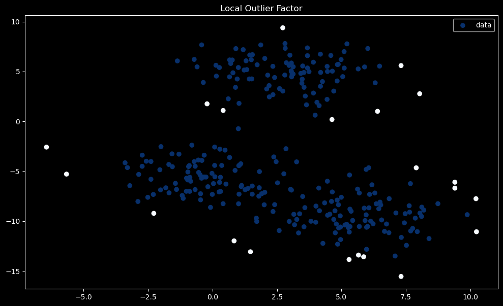

```python
plt.figure(figsize=(12, 7))
plt.scatter(all_data[:, 0], all_data[:, 1], c=all_data[:, 2], cmap='Blues', label='data')
plt.title('Local Outlier Factor')
plt.legend()
plt.show()
```

## LOF Scores:

The negative outlier factor scores are extracted from the LOF model. These scores represent how "outlying" each point is. Higher negative values indicate more outlier-like behavior.

## Radius Calculation:

A radius is calculated based on the LOF scores, which is used to visually scale the points in the next plot (larger circles for outliers).

```python
LOF_scores = lof.negative_outlier_factor_
radius = (LOF_scores.max() - LOF_scores) / (LOF_scores.max() - LOF_scores.min())
radius[:5]
```

```
array([0.03834082, 0.12830657, 0.1180624 , 0.24543848, 0.01556816])
```

**Here, the outliers are visualized by plotting larger circles around the outliers. The circle size is proportional to the radius calculated from the LOF scores. This helps in understanding the degree to which a point is considered an outlier.**

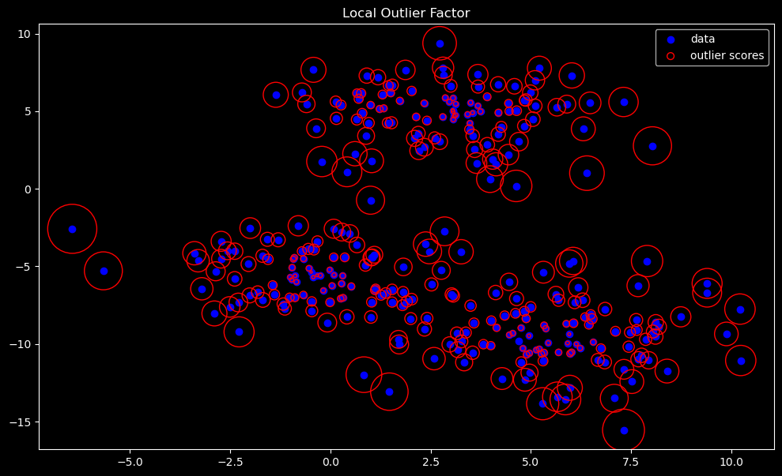

```python
plt.figure(figsize=(12, 7))
plt.scatter(all_data[:, 0], all_data[:, 1], label='data', c='blue')
plt.scatter(all_data[:, 0], all_data[:, 1], s=2000 * radius, edgecolors='r', facecolors='none', label='outlier scores')
plt.title('Local Outlier Factor')
legend = plt.legend()
legend.legend_handles[1]._sizes = [40]
plt.show()
```

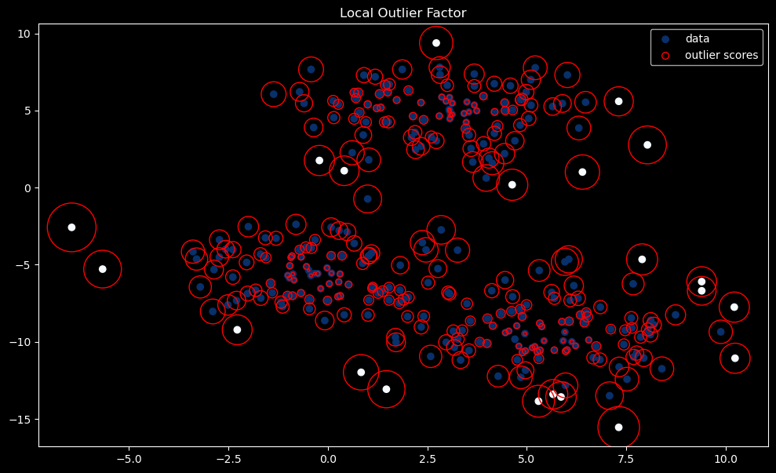

```python
plt.figure(figsize=(12, 7))
plt.scatter(all_data[:, 0], all_data[:, 1], c=all_data[:, 2], cmap='Blues', label='data')
plt.scatter(all_data[:, 0], all_data[:, 1], s=2000 * radius, edgecolors='r', facecolors='none', label='outlier scores')
plt.title('Local Outlier Factor')
legend = plt.legend()
legend.legend_handles[1]._sizes = [40]
plt.show()
```